# analisi popolazione italia v. 0.0.4

David Marabottini

2025-10-20

*Obiettivo*: Il seguente report analizza la struttura per età e l’impatto migratorio sulla popolazione residente in Italia nel 2025. Verranno confrontate piramidi di età su 3 tagli: residenti totali, residenti Stranieri e residenti Italiani

*Sorgente dei dati:* https://demo.istat.it/ su “popolazione residente” e “popolazione straniera residente”, per quanto riguarda la popolazione Italiana residente, è stato creato su excel come differenza tra le residenze totali e le residenze straniere

**I csv sono stati puliti, controllati e preelaborati con power query**

## Analisi integrità dei dati

### Verifica degli outliers

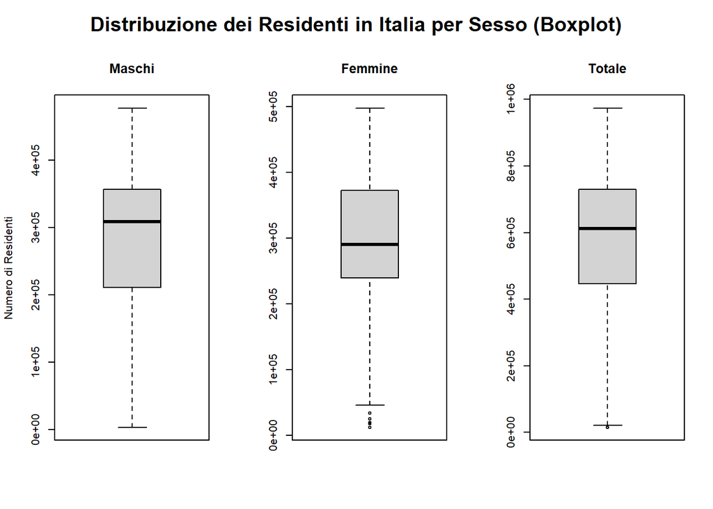

```
## [1] "Maschi"
## [1] "Quartili"
## [1]   0.00000  25.62194  46.43661  62.09620 100.00000
## Distanza interqurtile:  36.47426
## Range:  100
## [1] "Femmine"
## [1] "Quartili"
## [1]   0.00000  28.43486  49.49487  65.49420 100.00000
## Distanza interqurtile:  37.05934
## Range:  100
## [1] "Totale"
## [1] "Quartili"
## [1]   0.00000  26.95462  48.03033  63.80557 100.00000
## Distanza interqurtile:  36.85095
## Range:  100
```

Statistiche per Distribuzione dei Residenti in Italia per Sesso (Boxplot)

| Statistica | Maschi | Femmine | Totale |
| --- | --- | --- | --- |
| Media Età | 44.91 | 47.73 | 46.35 |
| Varianza | 534.25 | 570.02 | 554.48 |
| Deviazione standard | 23.11 | 23.88 | 23.88 |
| N° Outlier | 0.00 | 5.00 | 1.00 |

### Piramide popolazione

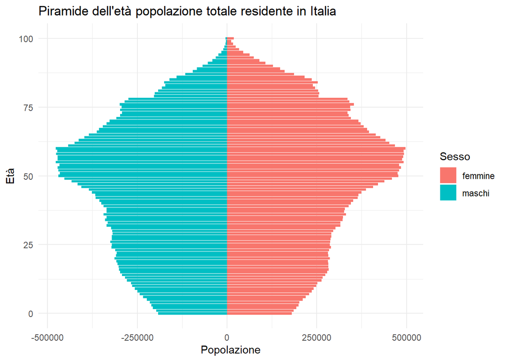

### Dati vecchiaia

| totale | under_14 | under_14_perc | over_65 | over_65_perc |
| --- | --- | --- | --- | --- |
| 58934177 | 7019165 | 11.91018 | 14573173 | 24.72788 |

```
## Indice vecchiaia:  207.6198
```

L’età media è di 46 anni mentre l’indice di vecchiaia è a 207.

## Un indice sopra i 100 vuol dire che gli over 65 sono molti di più rispetto agli under 14, un indice a 207 indica che questi sono più del doppio, ciò contribuisce ad alzare significativamente l’età media

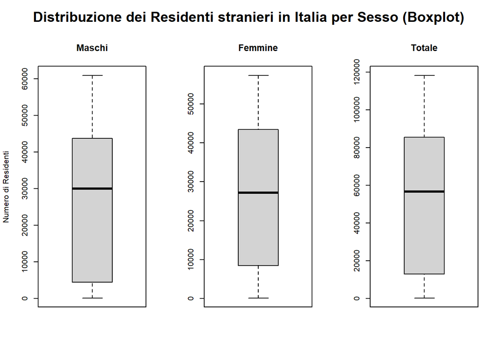

```
## [1] "Maschi"
## [1] "Quartili"
## [1]   0.00000  21.19148  34.41936  46.22793 100.00000
## Distanza interqurtile:  25.03645
## Range:  100
## [1] "Femmine"
## [1] "Quartili"
## [1]   0.00000  24.44421  38.91732  51.80361 100.00000
## Distanza interqurtile:  27.3594
## Range:  100
## [1] "Totale"
## [1] "Quartili"
## [1]   0.00000  22.64956  36.60314  48.98833 100.00000
## Distanza interqurtile:  26.33877
## Range:  100
```

Statistiche per Distribuzione dei Residenti stranieri in Italia per Sesso (Boxplot)

| Statistica | Maschi | Femmine | Totale |
| --- | --- | --- | --- |
| Media Età | 34.30 | 38.23 | 36.26 |
| Varianza | 318.50 | 375.74 | 350.89 |
| Deviazione standard | 17.85 | 19.38 | 19.38 |
| N° Outlier | 0.00 | 0.00 | 0.00 |

La maggior parte dei residenti stranieri sembra concentrata nella fascia di età tra 20 e 50 anni, con una distanza interquartile per gli uomini di 25 anni e per le donne di 27. Sembra che le donne siano più anziane degli uomini, con una mediana che sta a 39 anni, contro i 34 degli uomini.

L’età media risulta abbastanza allineata alla mediana, con 34 anni per gli uomini e 38 per le donne.

L’allineamento di media e mediana, la deviazione standard (18, 19) e distanza interquartile basse rispetto al range (100) rendono media e mediana buoni indicatori per l’età dello straniero medio

## Analisi sulla popolazione Straniera residente in Italia

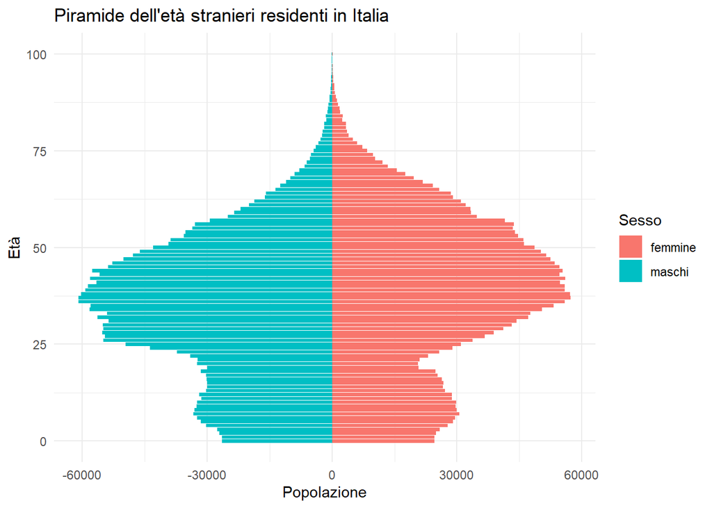

**dati vecchiaia**

| totale | under_14 | under_14_perc | over_65 | over_65_perc |
| --- | --- | --- | --- | --- |
| 5422426 | 875057 | 16.13774 | 344995 | 6.362374 |

```
## Indice vecchiaia:  39.42543
```

## Questo indica che tra gli stranieri gli under 14 sono più del doppio degli over 65

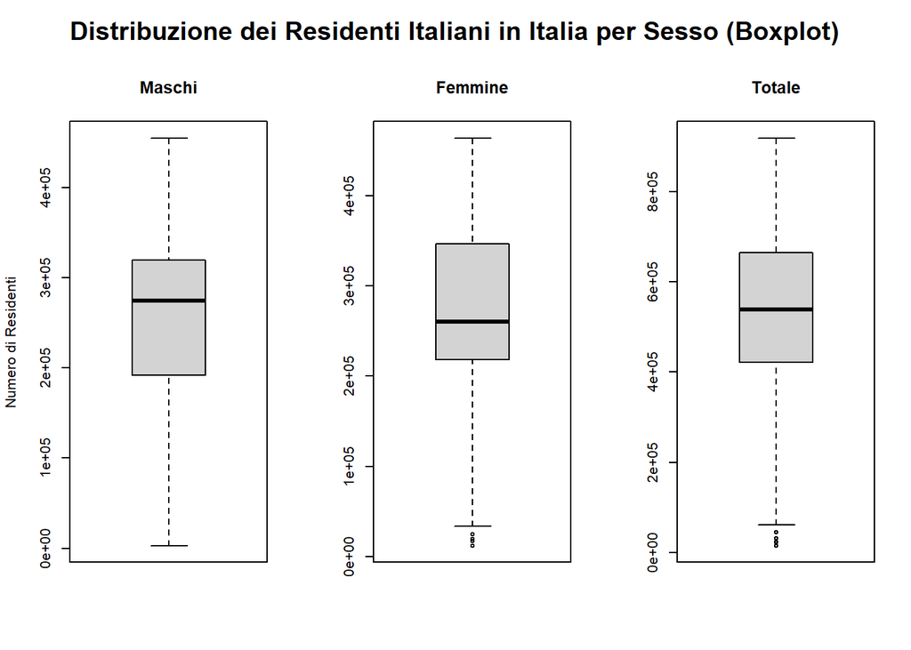

```
## [1] "Maschi"
## [1] "Quartili"
## [1]   0.00000  26.33824  48.24227  63.45303 100.00000
## Distanza interqurtile:  37.1148
## Range:  100
## [1] "Femmine"
## [1] "Quartili"
## [1]   0.00000  29.01410  50.81812  66.80905 100.00000
## Distanza interqurtile:  37.79494
## Range:  100
## [1] "Totale"
## [1] "Quartili"
## [1]   0.00000  27.63335  49.55146  65.12453 100.00000
## Distanza interqurtile:  37.49118
## Range:  100
```

Statistiche per Distribuzione dei Residenti Italiani in Italia per Sesso (Boxplot)

| Statistica | Maschi | Femmine | Totale |
| --- | --- | --- | --- |
| Media Età | 46.01 | 48.67 | 47.37 |
| Varianza | 543.76 | 579.43 | 563.75 |
| Deviazione standard | 23.32 | 24.07 | 24.07 |
| N° Outlier | 0.00 | 4.00 | 5.00 |

La maggior parte dei residenti Italiani sembra concentrata nella fascia di età tra 27 e 65 anni, con una distanza interquartile di 37 anni. Sembra che le donne siano più anziane degli uomini, pur avendo di fatto la stessa distanza interquartile, come se questa fosse lievemente traslata

L’età media e la mediana sono distanti di 2 anni sia per gli uomini (46 - 48) che per le donne (49 - 51) mentre la deviazione standard risulta a 23 per gli uomini e 24 per le donne

Qui la situazione anagrafica risulta più eterogenea, anche se mediamente con una fascia più alta dell’età

## Analisi sulla popolazione Italiana residente in Italia

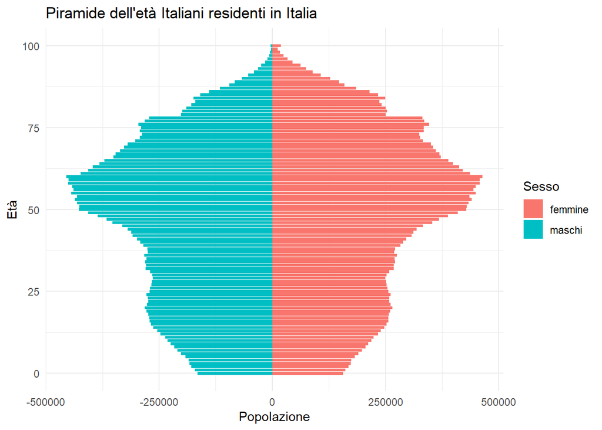

Filtrando solo gli Italiani, la piramide conferma la forte decrescita nelle classi di età più giovane. L’assenza della componente straniera mostra ancor di più l’inverno demografico che si sta configurando in Italia

**dati vecchiaia**

| totale | under_14 | under_14_perc | over_65 | over_65_perc |
| --- | --- | --- | --- | --- |
| 53511751 | 6144108 | 11.48179 | 14228178 | 26.58889 |

```
## Indice vecchiaia:  231.5743
```

L’età media è a 47 mentre l’indice di vecchiaia (non mitigato) è a 231, che vuol dire un peggioramento importante della situazione rispetto ai dati presi su tutta la popolazione residente

## Percentuale della popolazione Straniera in Italia ripartita per età

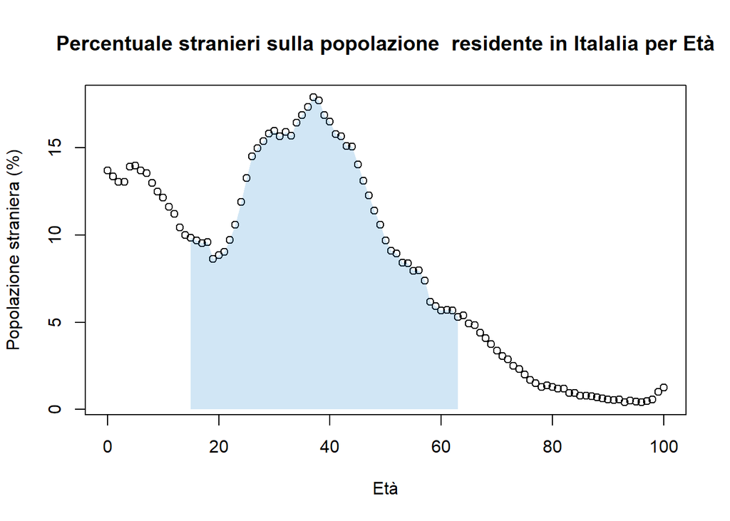

In questo grafico mostro la percentuale di stranieri rispetto alla popolazione.

Ho evidenziato la fascia 15, 64 anni in quanto è la fascia lavorativa.

è evidente che la quantità di stranieri supera la soglia del 10% tra le fasce giovani

## Ulteriori informazioni

```
## Ci sono  196 Cittadinanze in Italia
```

```
## Di seguito le prime 5 per numero di persone
```

| Anno | Cittadinanza | Totale |
| --- | --- | --- |
| 2024 | Italia | 91.09 |
| 2024 | Romania | 1.82 |
| 2024 | Albania | 0.71 |
| 2024 | Marocco | 0.70 |
| 2024 | Cina | 0.52 |

## Conclusioni

Sarebbe interessante incrociare questi dati con dati economici per avere conferme o smentite circa il beneficio apportato nella situazione economica Italiana.